# PS 9

Ilayda Koca

2022-11-14

## Getting Set Up

If you haven’t already, create a folder for this course, and then a subfolder called `Topic10_Classification`, and two additional subfolders within `code` and `data`.

Open `RStudio` and create a new RMarkDown file (`.Rmd`) by going to `File -> New File -> R Markdown...`. Change the title to `"DS1000: Problem Set 9"` and the author to your full name. Save this file as `[LAST NAME]_ps9.Rmd` to your `code` folder.

If you haven’t already, download the `admit_data.rds` file from the course [github page](https://github.com/jbisbee1/DS1000-F2022/blob/master/Lectures/Topic10_Classification/data/admit_data.rds) and save it to your `data` folder.

Require the `tidyverse` & `tidymodels` packages, and load the `admit_data.rds` data to `ad`. Finally, `set.seed(123)` once at the very beginning, to ensure consistency in results throughout the problem set.

```r
require(tidyverse)
require(tidymodels)
ad <-  readRDS('../data/admit_data.rds')
set.seed(123)
glimpse(ad)
```

```
## Rows: 2,150
## Columns: 14
## $ ID          <chr> "0001", "0002", "0003", "0004", "0005", "0006", "0007", "0…
## $ income      <dbl> 289720.59, 176763.29, 81204.02, 93320.52, 144991.22, 72720…
## $ sat         <dbl> 1107.403, 1387.607, 1000.000, 1134.883, 1202.686, 1053.033…
## $ gpa         <dbl> 3.597153, 4.000000, 3.072323, 3.682776, 3.970005, 3.474787…
## $ visit       <dbl> 0, 0, 0, 1, 1, 0, 0, 0, 1, 0, 1, 0, 0, 1, 1, 0, 0, 1, 0, 0…
## $ legacy      <dbl> 1, 0, 0, 0, 0, 0, 0, 0, 0, 0, 0, 0, 0, 0, 1, 0, 0, 1, 0, 1…
## $ registered  <dbl> 1, 1, 0, 1, 1, 0, 0, 1, 0, 0, 1, 1, 0, 0, 1, 0, 0, 1, 1, 1…
## $ sent_scores <dbl> 0, 0, 1, 0, 0, 1, 1, 0, 0, 0, 0, 0, 0, 0, 0, 0, 0, 0, 0, 0…
## $ distance    <dbl> 10.23279, 89.75984, 152.29961, 317.50274, 240.30712, 63.07…
## $ tuition     <dbl> 45000, 45000, 45000, 45000, 45000, 45000, 45000, 45000, 45…
## $ need_aid    <dbl> 0.000, 0.000, 8488.293, 3338.779, 0.000, 12093.802, 15156.…
## $ merit_aid   <dbl> 0.00, 35190.18, 0.00, 0.00, 30567.16, 0.00, 31633.66, 3219…
## $ net_price   <dbl> 45000.000, 9809.815, 36511.707, 41661.221, 14432.840, 3290…
## $ yield       <int> 1, 1, 1, 0, 1, 0, 1, 1, 0, 0, 0, 1, 0, 1, 1, 0, 0, 1, 1, 0…
```

## Question 1 [4 points + 3 EC points]

Plot the univariate visualizations for `yield`, `income`, and `sat`. Justify your choices for how you are visualizing these variables. Then plot the conditional variation between `yield` and `income`, and `yield` and `sat`. Again, justify your choices and then interpret the results. Do these variables matter for `yield`?

EXTRA CREDIT (+1 point): Explain the pattern you observe in the uni-variate visualization of the SAT scores. What might explain this?

EXTRA CREDIT (+2 points): Look at these same conditional relationships between `yield` and `income` and `sat`, except divide the continuous measures of `income` and `sat` into deciles using the `ntile()` function, and create a single heatmap for all three variables, where the deciles of `income` and `sat` are on the axes, and the tiles are shaded by the average attendance in each cell. Which students are most likely to attend? Which are least likely to attend? Can you determine whether income or SAT scores matter more for attendance based on this plot?

**HINTS**:

- Univariate Description [part 1](https://www.jamesbisbee.com/DS1000-F2022/Lectures/Topic5_UnivariateDescription/code/Topic5_UnivariateDescription_part1_slides.html#1) and Univariate Visualization [part 2](https://www.jamesbisbee.com/DS1000-F2022/Lectures/Topic6_UnivariateVisualization/code/Topic6_UnivariateVisualization_part2_slides.html#1)
- Conditional Variation [part 1](https://www.jamesbisbee.com/DS1000-F2022/Lectures/Topic7_ConditionalVariation/code/Topic7_ConditionalVariation_part1_slides.html#1) and [part 2](https://www.jamesbisbee.com/DS1000-F2022/Lectures/Topic7_ConditionalVariation/code/Topic7_ConditionalVariation_part2_slides.html#5)
- [Heatmap example](https://www.jamesbisbee.com/DS1000-F2022/Lectures/Topic10_Classification/code/Topic10_Classification_part1_slides.html#69)

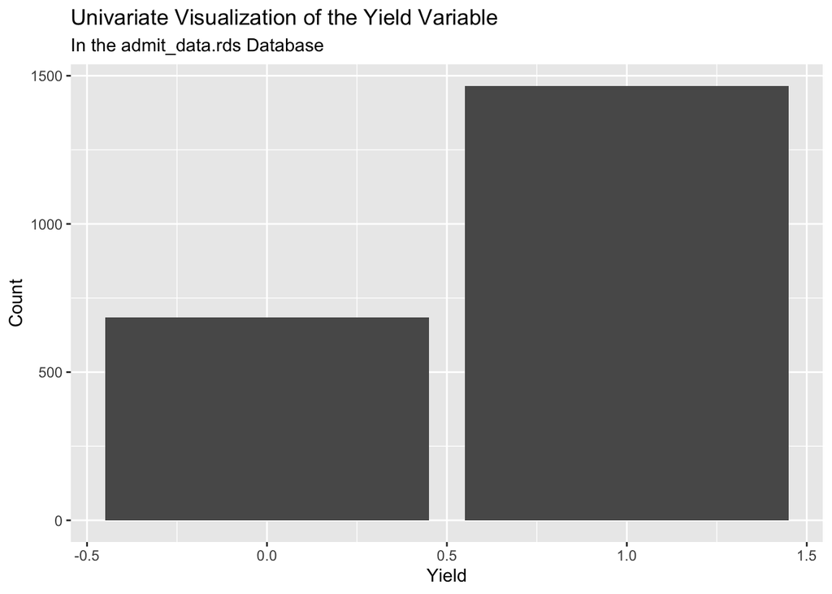

```r
p1 <- ad %>%
  ggplot(aes(x=yield)) +
  geom_bar() +
  labs(x = 'Yield',
       y = 'Count',
       title = 'Univariate Visualization of the Yield Variable',
       subtitle = 'In the admit_data.rds Database')

p1
```

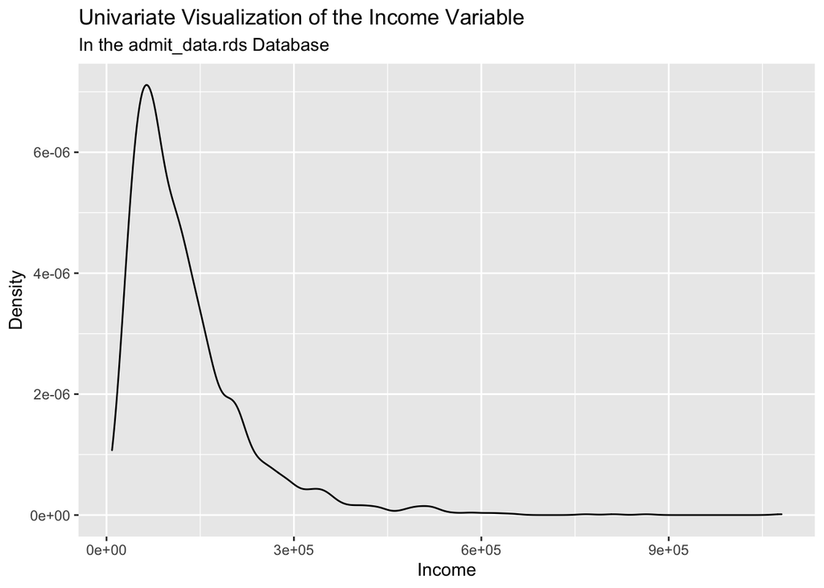

```r
p2 <- ad %>%
  ggplot(aes(x=income)) +
  geom_density() +
  labs(x = 'Income',
       y = 'Density',
       title = 'Univariate Visualization of the Income Variable',
       subtitle = 'In the admit_data.rds Database')

p2
```

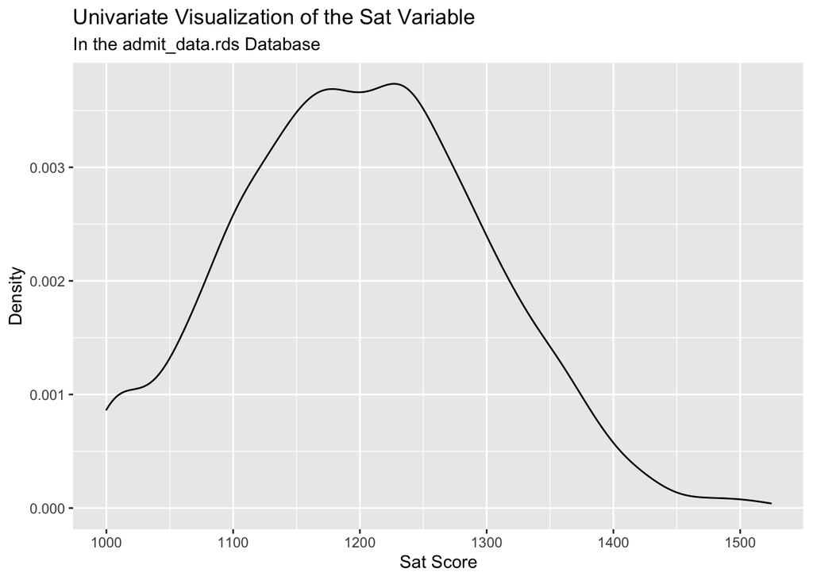

```r
p3 <- ad %>%
  ggplot(aes(x=sat)) +
  geom_density() +
  labs(x = 'Sat Score',
       y = 'Density',
       title = 'Univariate Visualization of the Sat Variable',
       subtitle = 'In the admit_data.rds Database')

p3
```

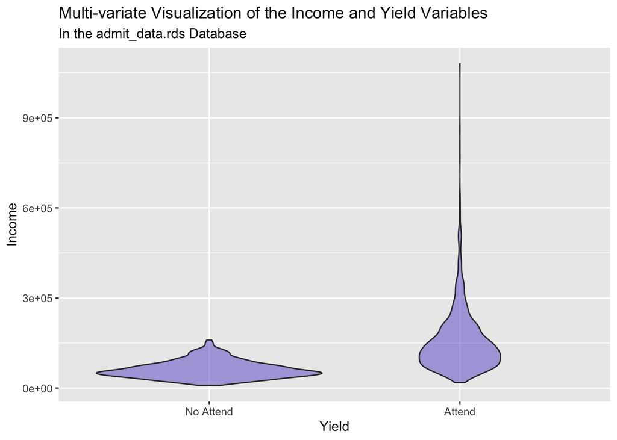

```r
p4 <- ad %>%
    ggplot(aes(x= factor(yield), y = income)) +
    geom_violin(fill = "slateblue",alpha = .5) +
    scale_x_discrete(name = 'Yield',labels = c('No Attend','Attend')) +
    labs(x = 'Yield',
       y = 'Income',
       title = 'Multi-variate Visualization of the Income and Yield Variables ',
       subtitle = 'In the admit_data.rds Database')
p4
```

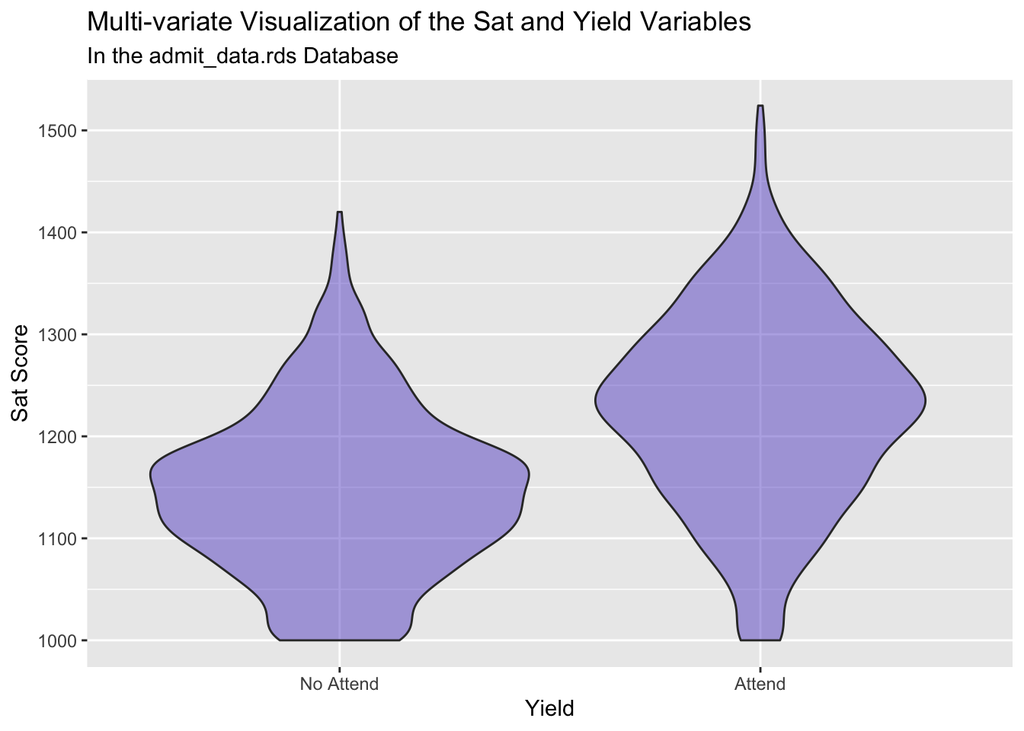

```r
p5 <- ad %>%
    ggplot(aes(x= factor(yield), y = sat)) +
    geom_violin(fill = "slateblue",alpha = .5) +
    scale_x_discrete(name = 'Yield',labels = c('No Attend','Attend')) +
    labs(x = 'Yield',
       y = 'Sat Score',
       title = 'Multi-variate Visualization of the Sat and Yield Variables ',
       subtitle = 'In the admit_data.rds Database')

p5
```

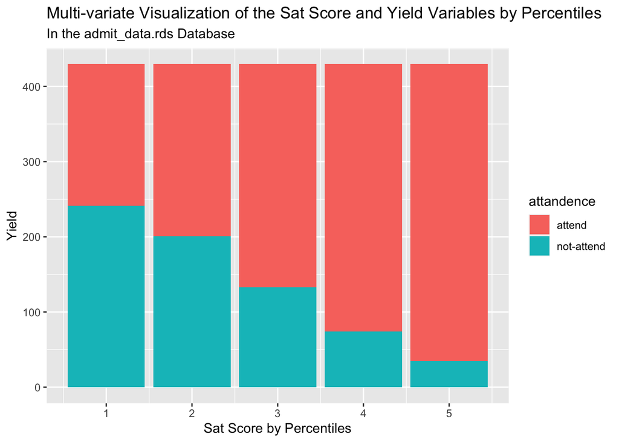

```r
## Extra credit
# Look at these same conditional relationships between `yield` and `income` and `sat`, except divide the continuous measures of `income` and `sat` into deciles using the `ntile()` function

p6 <- ad %>%
  mutate(sat_quintile=ntile(sat,n=5)) %>%
  mutate(attandence = ifelse(yield == 1, "attend", "not-attend")) %>%
  ggplot(aes(x= sat_quintile, fill = attandence)) +
  geom_bar() +
  labs(x = 'Sat Score by Percentiles',
       y = 'Yield',
       title = 'Multi-variate Visualization of the Sat Score and Yield Variables by Percentiles',
       subtitle = 'In the admit_data.rds Database')

p6
```

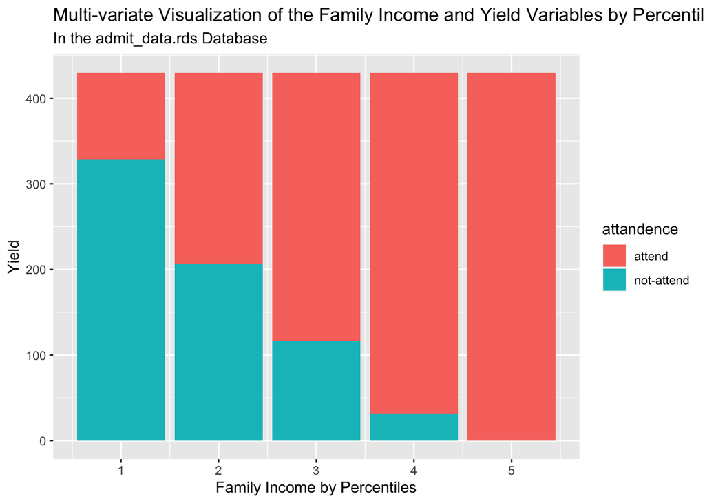

```r
p7 <- ad %>%
  mutate(income_quintile=ntile(income,n=5)) %>%
  mutate(attandence = ifelse(yield == 1, "attend", "not-attend")) %>%
  ggplot(aes(x= income_quintile, fill = attandence)) +
  geom_bar() +
  labs(x = 'Family Income by Percentiles',
       y = 'Yield',
       title = 'Multi-variate Visualization of the Family Income and Yield Variables by Percentiles',
       subtitle = 'In the admit_data.rds Database')

p7
```

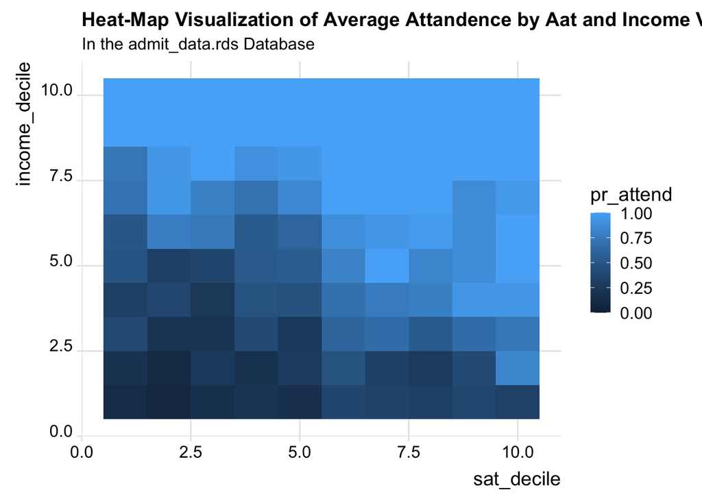

```r
# Create a single heat-map for all three variables, where the deciles of `income` and `sat` are on the axes, and the tiles are shaded by the average attendance in each cell.
require(ggridges)
p <- ad %>%
  mutate(sat_decile = ntile(sat,n=10)) %>%
  mutate(income_decile = ntile(income,n=10)) %>%
  group_by(sat_decile,income_decile) %>%
  summarise(pr_attend = mean(yield),.groups = 'drop') %>%
  ggplot(aes(x = sat_decile, y = income_decile,
             fill = pr_attend)) +
  geom_tile() +
  scale_fill_gradient(limits = c(0,1)) +
  theme_ridges() +
  labs(title = 'Heat-Map Visualization of Average Attandence by Aat and Income Variables ',
       subtitle = 'In the admit_data.rds Database')

p
```

## Question 2 [4 points]

Now start with the simplest way of predicting attendance: the conditional mean. Specifically, calculate declines for `income` and `sat` called `incomeDec` and `satDec` using the `ntile()` function. Then calculate the average attendance in each cell using `group_by()` and `mutate()`, and finally predict attendance as 1 if the average is greater than 0.5, and 0 otherwise, using an `ifelse()` function. Evaluate the performance in terms of **accuracy**, **sensitivity**, and **specificity**. Finally, define these terms and describe your results for a general audience reader who doesn’t understand statistics.

**HINTS**:

- [Conditional means](https://www.jamesbisbee.com/DS1000-F2022/Lectures/Topic10_Classification/code/Topic10_Classification_part1_slides.html#72)
- [Sensitivity & Specificity](https://www.jamesbisbee.com/DS1000-F2022/Lectures/Topic10_Classification/code/Topic10_Classification_part1_slides.html#90)

```r
ad <- ad %>%
  mutate(satDec = ntile(sat,n = 10),
         incomeDec = ntile(income,n = 10)) %>%
  group_by(satDec,incomeDec) %>%
  mutate(prob_attend = mean(yield)) %>%
  ungroup() %>%
  mutate(pred_attend = ifelse(prob_attend > .5,1,0))

ad %>%
  group_by(yield,pred_attend) %>%
  summarise(nStudents = n())
```

```
## # A tibble: 4 × 3
## # Groups:   yield [2]
##   yield pred_attend nStudents
##   <int>       <dbl>     <int>
## 1     0           0       535
## 2     0           1       149
## 3     1           0       211
## 4     1           1      1255
```

```r
#accuracy
accuracy <- ad %>%
  group_by(yield) %>%
  mutate(total_attend = n()) %>%
  group_by(yield,pred_attend,total_attend) %>%
  summarise(nStudents=n(),.groups = 'drop') %>%
  mutate(prop = nStudents / total_attend) %>%
  mutate(accuracy = percent(sum((yield == pred_attend)*nStudents) / sum(nStudents)))

accuracy
```

```
## # A tibble: 4 × 6
##   yield pred_attend total_attend nStudents  prop accuracy
##   <int>       <dbl>        <int>     <int> <dbl> <chr>
## 1     0           0          684       535 0.782 83%
## 2     0           1          684       149 0.218 83%
## 3     1           0         1466       211 0.144 83%
## 4     1           1         1466      1255 0.856 83%
```

```r
#sensitivity
sensitivity <- ad %>%
  group_by(yield) %>%
  filter(yield == 1) %>%
  mutate(total_attend = n()) %>%
  group_by(yield,pred_attend,total_attend) %>%
  summarise(nStudents=n(),.groups = 'drop') %>%
  mutate(prop = nStudents / total_attend) %>%
  mutate(accuracy = percent(sum((yield == pred_attend)*nStudents) / sum(nStudents)))

sensitivity
```

```
## # A tibble: 2 × 6
##   yield pred_attend total_attend nStudents  prop accuracy
##   <int>       <dbl>        <int>     <int> <dbl> <chr>
## 1     1           0         1466       211 0.144 86%
## 2     1           1         1466      1255 0.856 86%
```

```r
#specificity
specificity <- ad %>%
  group_by(yield) %>%
  filter(yield == 0) %>%
  mutate(total_attend = n()) %>%
  group_by(yield,pred_attend,total_attend) %>%
  summarise(nStudents=n(),.groups = 'drop') %>%
  mutate(prop = nStudents / total_attend) %>%
  mutate(specificity = percent(sum((yield == pred_attend)*nStudents) / sum(nStudents)))

specificity
```

```
## # A tibble: 2 × 6
##   yield pred_attend total_attend nStudents  prop specificity
##   <int>       <dbl>        <int>     <int> <dbl> <chr>
## 1     0           0          684       535 0.782 78%
## 2     0           1          684       149 0.218 78%
```

> - Accuracy calculates the overall prediction including the prediction of both the attendees and the non-attendees. Sensitivity describes how accurate the prediction was in terms of correctly predicting the attendees and attendees alone. Conversely, specificity describes how accurate the prediction of the non-attendees was without taking the attendees into consideration.
> - The accuracy of our predictions was 83% when we predicted attendance based on the factors of family income and sat scores. This means that overall, for the 83% of the data points, the predicted attendance value was the same as the actual attendance value. In other words, our prediction model incorrectly predicted attending students as non-attending and non-attending students as attending only for 17% of the time in total.
> - The sensitivity of our predictions was 86% when we predicted attendance based on the factors of family income and sat scores. This means that when we limited the data to only the students that are attending, our data was able to correctly predict for the 86% of the time that the student was attending. In other words, our prediction model incorrectly predicted an attending student to be non-attending for only 14% of the time.
> - The specificity of our predictions was 78% when we predicted attendance based on the factors of family income and sat scores. This means that when we limited the data to only the students that are non-attending, our data was able to correctly predict the attendance status of a student for 78% of the time. In other words, our prediction model incorrectly predicted an non-attending student to be attending for only 22% of the time.

## Question 3 [4 points]

Now predict whether students will attend using a linear regression model (using the `lm()` function) that predicts `yield` as a function of `income` and `sat` (**not** using deciles, just the continuous versions). Calculate **accuracy**, **sensitivity**, and **specificity** from this model where the threshold is again 0.5, and compare to the results from Question 3. Does this model do better?

**HINTS**:

- [Linear regression for classification](https://www.jamesbisbee.com/DS1000-F2022/Lectures/Topic10_Classification/code/Topic10_Classification_part1_slides.html#81)

```r
mLM <- lm(yield ~ sat + income, ad)
summary(mLM)
```

```
##
## Call:
## lm(formula = yield ~ sat + income, data = ad)
##
## Residuals:
##     Min      1Q  Median      3Q     Max
## -1.6789 -0.4099  0.1318  0.3224  0.7381
##
## Coefficients:
##               Estimate Std. Error t value Pr(>|t|)
## (Intercept) -1.140e+00  1.056e-01  -10.79   <2e-16 ***
## sat          1.329e-03  8.966e-05   14.82   <2e-16 ***
## income       1.796e-06  9.005e-08   19.95   <2e-16 ***
## ---
## Signif. codes:  0 '***' 0.001 '**' 0.01 '*' 0.05 '.' 0.1 ' ' 1
##
## Residual standard error: 0.3962 on 2147 degrees of freedom
## Multiple R-squared:  0.2775, Adjusted R-squared:  0.2768
## F-statistic: 412.3 on 2 and 2147 DF,  p-value: < 2.2e-16
```

```r
ad %>%
  mutate(preds = predict(mLM)) %>%
  mutate(predBinary = ifelse(preds > .5,1,0)) %>%
  select(yield,predBinary,preds)
```

```
## # A tibble: 2,150 × 3
##    yield predBinary preds
##    <int>      <dbl> <dbl>
##  1     1          1 0.851
##  2     1          1 1.02
##  3     1          0 0.334
##  4     0          1 0.535
##  5     1          1 0.718
##  6     0          0 0.389
##  7     1          1 0.632
##  8     1          1 1.07
##  9     0          0 0.404
## 10     0          1 0.546
## # … with 2,140 more rows
```

```r
accuracy <- ad %>%
  mutate(pred_attend = ifelse(predict(mLM) > .5,1,0)) %>%
  group_by(yield) %>%
  mutate(total_attend = n()) %>%
  group_by(yield,pred_attend,total_attend) %>%
  summarise(nStudents=n(),.groups = 'drop') %>%
  mutate(prop = nStudents / total_attend) %>%
  ungroup() %>%
  mutate(accuracy = percent(sum((yield == pred_attend)*nStudents) / sum(nStudents)))

accuracy
```

```
## # A tibble: 4 × 6
##   yield pred_attend total_attend nStudents   prop accuracy
##   <int>       <dbl>        <int>     <int>  <dbl> <chr>
## 1     0           0          684       366 0.535  80%
## 2     0           1          684       318 0.465  80%
## 3     1           0         1466       121 0.0825 80%
## 4     1           1         1466      1345 0.917  80%
```

```r
sensitivity <- ad %>%
  mutate(pred_attend = ifelse(predict(mLM) > .5,1,0)) %>%
  group_by(yield) %>%
  filter(yield == 1) %>%
  mutate(total_attend = n()) %>%
  group_by(yield,pred_attend,total_attend) %>%
  summarise(nStudents=n(),.groups = 'drop') %>%
  mutate(prop = nStudents / total_attend) %>%
  ungroup() %>%
  mutate(sensitivity = percent(sum((yield == pred_attend)*nStudents) / sum(nStudents)))

sensitivity
```

```
## # A tibble: 2 × 6
##   yield pred_attend total_attend nStudents   prop sensitivity
##   <int>       <dbl>        <int>     <int>  <dbl> <chr>
## 1     1           0         1466       121 0.0825 92%
## 2     1           1         1466      1345 0.917  92%
```

```r
specificity <- ad %>%
  mutate(pred_attend = ifelse(predict(mLM) > .5,1,0)) %>%
  group_by(yield) %>%
  filter(yield == 0) %>%
  mutate(total_attend = n()) %>%
  group_by(yield,pred_attend,total_attend) %>%
  summarise(nStudents=n(),.groups = 'drop') %>%
  mutate(prop = nStudents / total_attend) %>%
  ungroup() %>%
  mutate(specificity = percent(sum((yield == pred_attend)*nStudents) / sum(nStudents)))

specificity
```

```
## # A tibble: 2 × 6
##   yield pred_attend total_attend nStudents  prop specificity
##   <int>       <dbl>        <int>     <int> <dbl> <chr>
## 1     0           0          684       366 0.535 54%
## 2     0           1          684       318 0.465 54%
```

> - In terms of the overall accuracy the linear regression model does a worse job at prediction (80% accuracy) than the most basic conditional mean predictions (83% accuracy). For the sensitivity measure, the linear regression model does a better job at prediction (92% accuracy) than the most basic conditional mean predictions (86% accuracy). Finally, for the specificity measure, linear regression model does a worse job at prediction (54% accuracy) than the most basic conditional mean predictions (78% accuracy).

## Question 4 [4 points]

Now recalculate **sensitivity**, **specificity**, and **accuracy** using different thresholds, ranging from 0 to 1, incrementing by 0.025 (use the `seq(from,to,by)` function). Plot the relationship between these thresholds and both the sensitivity and the specificity. What is the optimal threshold to balance the trade-off between **sensitivity** and **specificity**? Then plot ROC Curve and calculate the AUC.

**HINTS**:

- [Threshold loop](https://www.jamesbisbee.com/DS1000-F2022/Lectures/Topic10_Classification/code/Topic10_Classification_part1_slides.html#95)
- [ROC](https://www.jamesbisbee.com/DS1000-F2022/Lectures/Topic10_Classification/code/Topic10_Classification_part1_slides.html#97)
- [AUC](https://www.jamesbisbee.com/DS1000-F2022/Lectures/Topic10_Classification/code/Topic10_Classification_part1_slides.html#103)

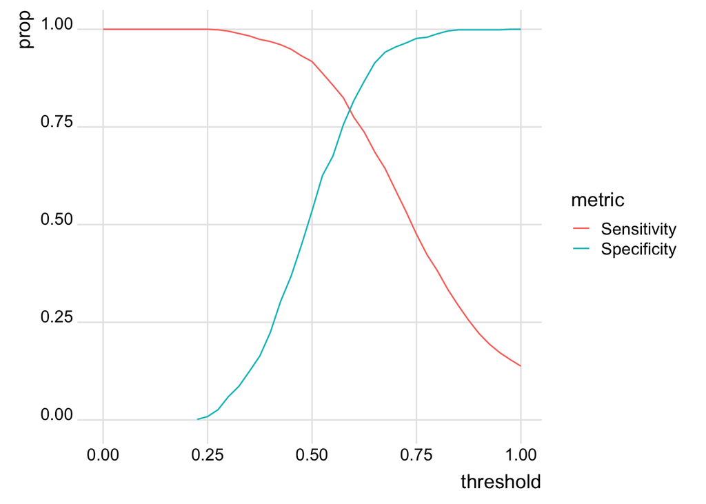

```r
# The Threshold loop
toplot <- NULL
for(thresh in seq(0,1,by = .025)) {
  toplot <- ad %>%
  mutate(pred_attend = ifelse(predict(mLM) > thresh,1,0)) %>%
  group_by(yield) %>%
  mutate(total_attend = n()) %>%
  group_by(yield,pred_attend,total_attend) %>%
  summarise(nStudents=n(),.groups = 'drop') %>%
  mutate(prop = nStudents / total_attend) %>%
  ungroup() %>%
  mutate(accuracy = sum((yield == pred_attend)*nStudents) / sum(nStudents)) %>%
  mutate(threshold = thresh) %>%
    bind_rows(toplot)
}

toplot %>%
  mutate(metric = ifelse(yield == 1 & pred_attend == 1,'Sensitivity',
                         ifelse(yield == 0 & pred_attend == 0,'Specificity',NA))) %>%
  drop_na(metric) %>%
  ggplot(aes(x = threshold,y = prop,color = metric)) +
  geom_line() +
  theme_ridges()
```

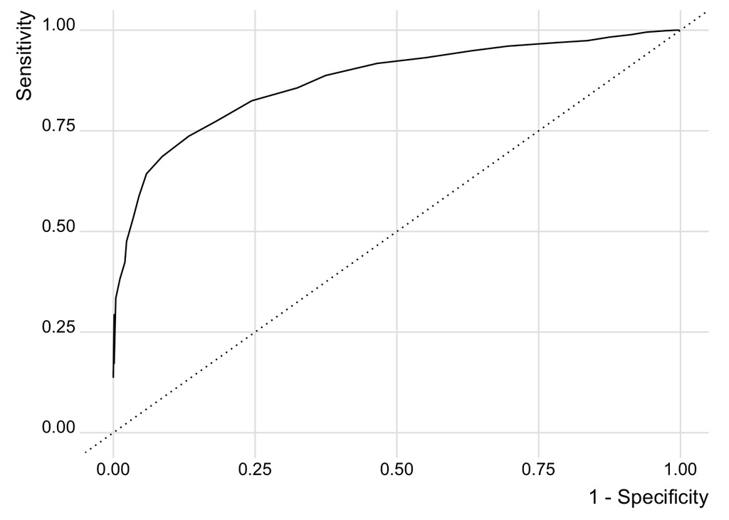

```r
#Roc Curve
p <- toplot %>%
  mutate(metric = ifelse(yield == 1 & pred_attend == 1,'Sensitivity',
                         ifelse(yield == 0 & pred_attend == 0,'Specificity',NA))) %>%
  drop_na(metric) %>%
  select(prop,metric,threshold) %>%
  spread(metric,prop) %>%
  ggplot(aes(x = 1-Specificity,y = Sensitivity)) +
  geom_line() +
  xlim(c(0,1)) + ylim(c(0,1)) +
  geom_abline(slope = 1,intercept = 0,linetype = 'dotted') +
  theme_ridges()
p
```

```r
#Auc Measure
roc_auc(data = ad %>%
  mutate(pred_attend = predict(mLM),
         truth = factor(yield,levels = c('1','0'))) %>%
  select(truth,pred_attend),truth,pred_attend)
```

```
## # A tibble: 1 × 3
##   .metric .estimator .estimate
##   <chr>   <chr>          <dbl>
## 1 roc_auc binary         0.875
```

> - The lines of sensitivity and specificity intersect at around the threshold value of 0.6. This means that the threshold value with the most accurate values of both sensitivity and specificity is 0.6.

## Question 5 [4 points]

Re-do questions 3 and 4 using a logistic regression. Does this perform better than a linear regression model?

**HINTS**:

- [Logit regression](https://www.jamesbisbee.com/DS1000-F2022/Lectures/Topic10_Classification/code/Topic10_Classification_part2_slides.html#35)

```r
# Train model
mLogit <- glm(formula = yield ~ sat + income,data = ad,family = binomial(link = 'logit'))
# Predict model
ad <- ad %>%
  mutate(prob_attend = predict(mLogit,type = 'response')) %>%
  mutate(pred_attend = ifelse(prob_attend > .5,1,0))

# Evaluate model
acc <- ad %>%
  group_by(yield) %>%
  mutate(total_attend = n()) %>%
  group_by(yield,pred_attend,total_attend) %>%
  summarise(nStudents=n(),.groups = 'drop') %>%
  mutate(prop = nStudents / total_attend) %>%
  ungroup() %>%
  mutate(accuracy = percent(sum((yield == pred_attend)*nStudents) / sum(nStudents)))

acc
```

```
## # A tibble: 4 × 6
##   yield pred_attend total_attend nStudents  prop accuracy
##   <int>       <dbl>        <int>     <int> <dbl> <chr>
## 1     0           0          684       493 0.721 83%
## 2     0           1          684       191 0.279 83%
## 3     1           0         1466       179 0.122 83%
## 4     1           1         1466      1287 0.878 83%
```

```r
sen <- ad %>%
  group_by(yield) %>%
  filter(yield == 1) %>%
  mutate(total_attend = n()) %>%
  group_by(yield,pred_attend,total_attend) %>%
  summarise(nStudents=n(),.groups = 'drop') %>%
  mutate(prop = nStudents / total_attend) %>%
  ungroup() %>%
  mutate(sensitivity = percent(sum((yield == pred_attend)*nStudents) / sum(nStudents)))

sen
```

```
## # A tibble: 2 × 6
##   yield pred_attend total_attend nStudents  prop sensitivity
##   <int>       <dbl>        <int>     <int> <dbl> <chr>
## 1     1           0         1466       179 0.122 88%
## 2     1           1         1466      1287 0.878 88%
```

```r
spe <- ad %>%
  group_by(yield) %>%
  filter(yield == 0) %>%
  mutate(total_attend = n()) %>%
  group_by(yield,pred_attend,total_attend) %>%
  summarise(nStudents=n(),.groups = 'drop') %>%
  mutate(prop = nStudents / total_attend) %>%
  ungroup() %>%
  mutate(specificity = percent(sum((yield == pred_attend)*nStudents) / sum(nStudents)))

spe
```

```
## # A tibble: 2 × 6
##   yield pred_attend total_attend nStudents  prop specificity
##   <int>       <dbl>        <int>     <int> <dbl> <chr>
## 1     0           0          684       493 0.721 72%
## 2     0           1          684       191 0.279 72%
```

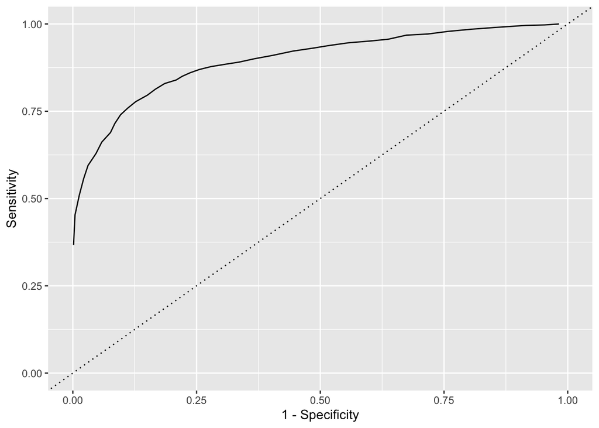

```r
#Roc Curve
toplot2 <- NULL
for(thresh in seq(0,1,by = .025)) {
  toplot2 <- ad %>%
    mutate(pred_attend = ifelse(predict(mLogit,type = 'response') > thresh,1,0)) %>%
    group_by(yield) %>%
    mutate(total_attend = n()) %>%
    group_by(yield,pred_attend,total_attend) %>%
    summarise(nStudents=n(),.groups = 'drop') %>%
    mutate(prop = nStudents / total_attend) %>%
    ungroup() %>%
    mutate(threshold = thresh) %>%
    bind_rows(toplot2)
}

p2 <- toplot2 %>%
  mutate(metric = ifelse(yield == 1 & pred_attend == 1,'Sensitivity',
                         ifelse(yield == 0 & pred_attend == 0,'Specificity',NA))) %>%
  drop_na(metric) %>%
  select(prop,metric,threshold) %>%
  spread(metric,prop) %>%
  ggplot(aes(x = 1-Specificity,y = Sensitivity)) +
  geom_line() +
  xlim(c(0,1)) + ylim(c(0,1)) +
  geom_abline(slope = 1,intercept = 0,linetype = 'dotted')

p2
```

```r
#Auc Measure
roc_auc(data = ad %>%
  mutate(prob_attend = predict(mLogit,type = 'response'),
         truth = factor(yield,levels = c('1','0'))) %>%
  select(truth,prob_attend),truth,prob_attend)
```

```
## # A tibble: 1 × 3
##   .metric .estimator .estimate
##   <chr>   <chr>          <dbl>
## 1 roc_auc binary         0.897
```

> - The AUC measure measures the total area under the ROC curve where the ROC curve is given as a Sensitivity versus Specificity graph. Better models always have a high levels of both sensitivity and specificity. Given all, we can conclude that models with higher AUC measures are better (more accurate) at predictions. Our linear regression model that predicted attendance based on the factors of sat scores and family income had an AUC measure of 87, while the logistic regression model that predicted attendance based on the factors of sat scores and family income had an AUC measure of 89. This shows that the logarithmic model did a better job at accurately predicting yield based on family income and sat scores.

## Question 6 [4 extra credit points]

Now redo questions 3 and 4 using a random forest via the `ranger` package. Interpret the results. Why should we not be over-excited by the AUC in this approach? What might you do to fix this issue?

```r
require(ranger)
# Train model
mRange <- ranger(yield ~ sat + income, ad)

# Predict model
pred <- predict(mRange,data = ad)
ad <- ad %>%
  mutate(prob_attend = pred$predictions) %>%
  mutate(pred_attend = ifelse(prob_attend > .5,1,0))

# Evaluate model
acc <- ad %>%
  group_by(yield) %>%
  mutate(total_attend = n()) %>%
  group_by(yield,pred_attend,total_attend) %>%
  summarise(nStudents=n(),.groups = 'drop') %>%
  mutate(prop = nStudents / total_attend) %>%
  ungroup() %>%
  mutate(accuracy = percent(sum((yield == pred_attend)*nStudents) / sum(nStudents)))

acc
```

```
## # A tibble: 4 × 6
##   yield pred_attend total_attend nStudents    prop accuracy
##   <int>       <dbl>        <int>     <int>   <dbl> <chr>
## 1     0           0          684       678 0.991   99%
## 2     0           1          684         6 0.00877 99%
## 3     1           0         1466         6 0.00409 99%
## 4     1           1         1466      1460 0.996   99%
```

```r
sen <- ad %>%
  group_by(yield) %>%
  filter(yield == 1) %>%
  mutate(total_attend = n()) %>%
  group_by(yield,pred_attend,total_attend) %>%
  summarise(nStudents=n(),.groups = 'drop') %>%
  mutate(prop = nStudents / total_attend) %>%
  ungroup() %>%
  mutate(sensitivity = percent(sum((yield == pred_attend)*nStudents) / sum(nStudents)))

sen
```

```
## # A tibble: 2 × 6
##   yield pred_attend total_attend nStudents    prop sensitivity
##   <int>       <dbl>        <int>     <int>   <dbl> <chr>
## 1     1           0         1466         6 0.00409 100%
## 2     1           1         1466      1460 0.996   100%
```

```r
spe <- ad %>%
  group_by(yield) %>%
  filter(yield == 0) %>%
  mutate(total_attend = n()) %>%
  group_by(yield,pred_attend,total_attend) %>%
  summarise(nStudents=n(),.groups = 'drop') %>%
  mutate(prop = nStudents / total_attend) %>%
  ungroup() %>%
  mutate(specificity = percent(sum((yield == pred_attend)*nStudents) / sum(nStudents)))

spe
```

```
## # A tibble: 2 × 6
##   yield pred_attend total_attend nStudents    prop specificity
##   <int>       <dbl>        <int>     <int>   <dbl> <chr>
## 1     0           0          684       678 0.991   99%
## 2     0           1          684         6 0.00877 99%
```

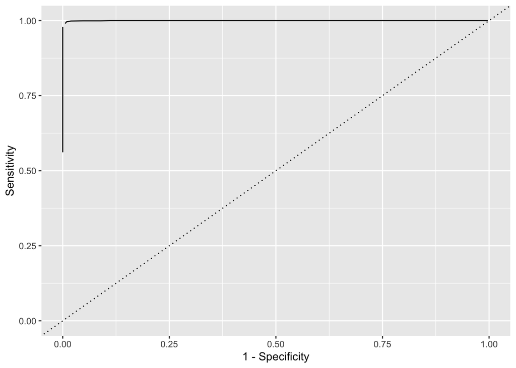

```r
#Roc Curve
toplot3 <- NULL
for(thresh in seq(0,1,by = .025)) {
  toplot3 <- ad %>%
    mutate(pred_attend = ifelse(pred$predictions > thresh,1,0)) %>%
    group_by(yield) %>%
    mutate(total_attend = n()) %>%
    group_by(yield,pred_attend,total_attend) %>%
    summarise(nStudents=n(),.groups = 'drop') %>%
    mutate(prop = nStudents / total_attend) %>%
    ungroup() %>%
    mutate(threshold = thresh) %>%
    bind_rows(toplot3)
}

p3 <- toplot3 %>%
  mutate(metric = ifelse(yield == 1 & pred_attend == 1,'Sensitivity',
                         ifelse(yield == 0 & pred_attend == 0,'Specificity',NA))) %>%
  drop_na(metric) %>%
  select(prop,metric,threshold) %>%
  spread(metric,prop) %>%
  ggplot(aes(x = 1-Specificity,y = Sensitivity)) +
  geom_line() +
  xlim(c(0,1)) + ylim(c(0,1)) +
  geom_abline(slope = 1,intercept = 0,linetype = 'dotted')

p3
```

```r
#Auc Measure
roc_auc(data = ad %>%
  mutate(prob_attend = pred$predictions,
         truth = factor(yield,levels = c('1','0'))) %>%
  select(truth,prob_attend),truth,prob_attend)
```

```
## # A tibble: 1 × 3
##   .metric .estimator .estimate
##   <chr>   <chr>          <dbl>
## 1 roc_auc binary          1.00
```

> - The AUC of 99.98 might be worrisome since no prediction is perfect.